# Lukasz Grabarski HW3

Łukasz Grabarski

2022-11-22

# 1. Opis badania

> Celem mojego eksperymentu było zbadanie wpływu zmiany skali na osi na odbiór danych z wykresu. Interesował mnie wpływ na czytelność wykresu oraz na wiarygodność przedstawionych informacji. W tym celu stworzyłem dwa wykresy przedstawiające te same wartości, natomiast różniące się początkiem osi OY.

# 2. Dane

> Do stowrzenia wykresów użyłem danych dotyczących wskaźnika punktualności przyjazdów pociągów PKP we wrześniu 2022. Korzystałem z informacji udostępnionych przez [Urząd Transortu Kolejowego](https://dane.utk.gov.pl/sts/punktualnosc/punktualnosc-pasazerska/19431,Punktualnosc-przewozow-pasazerskich.html). Wskaźnik punktualności na przybyciu stanowi iloraz sumy liczby wszystkich pociągów punktualnych i opóźnionych do 5 minut 59 sekund oraz liczby wszystkich pociągów uruchomionych. Przyjmuje wartości od 0 do 1. Do stworzenia wykresów wybrałem stacje, na których zatrzymało się ponad 10000 pociągów oraz współczynnik punktualności był większy niż 0.83. Oba wykresy przedstawiają współczynnik punktulaności dla stacji w tej samej kolejności. Pozycje nie zostały posortowane, aby odbiorca posługiwał się wyłącznie wysokością słupków, a nie kolejnośćią występowania.

# 3. Ankieta

> Ankieta składała się z 6 pytań podzielonych na 3 sekcje. Na początku została umieszczona krótka informacja dotycząca danych, w celu zapoznania odbiorcy z informacjami, które przedstawiały badane wykresy: “Wskaźnik punktualności na przybyciu stanowi iloraz sumy liczby wszystkich pociągów punktualnych i opóźnionych do 5 minut 59 sekund oraz liczby wszystkich pociągów uruchomionych. Przyjmuje wartości od 0 do 1. Dane pochodzą ze strony Urzędu Transportu Kolejowego i dotyczą września 2022r.”. Pytania 1, 3, 5 miały na celu sprawdzenie wpływu na czytelność, natiomist pytania 2, 4, 6 sprawdzały wpływ na subiektywny odbiór danych. Ankietę wypełniło 16 osób.

## Sekcja nr 1 dotyczyła wykresu nr 1

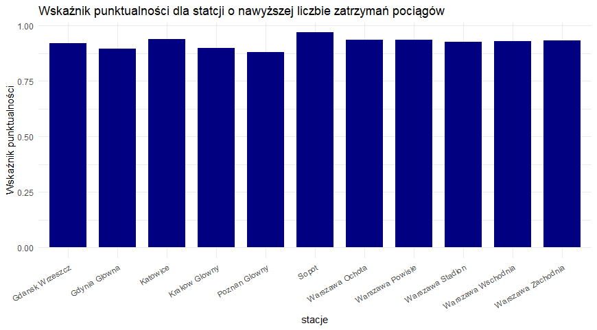

Wykres nr 1

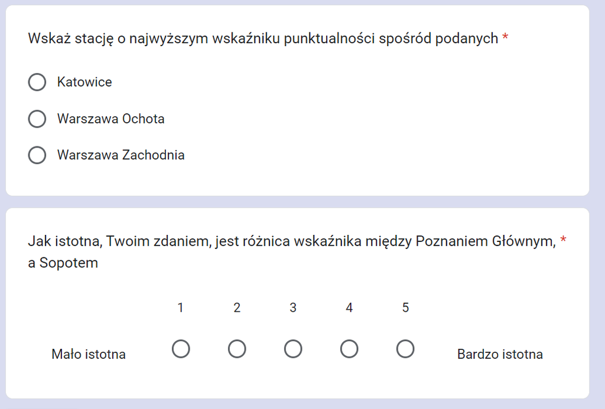

Pytania w sekcji nr 1

Pytanie nr 1

Pytanie nr 2

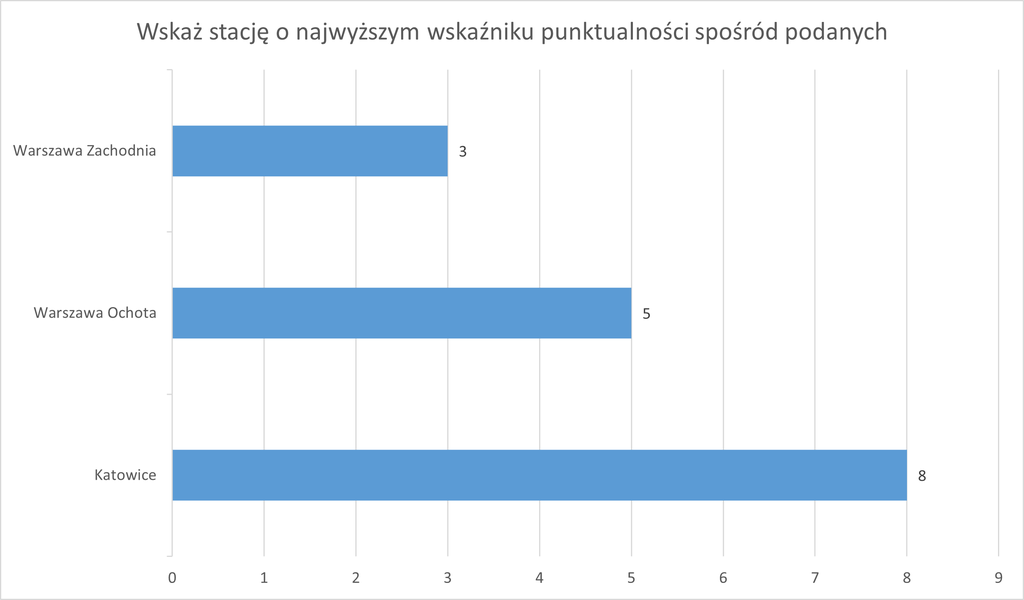

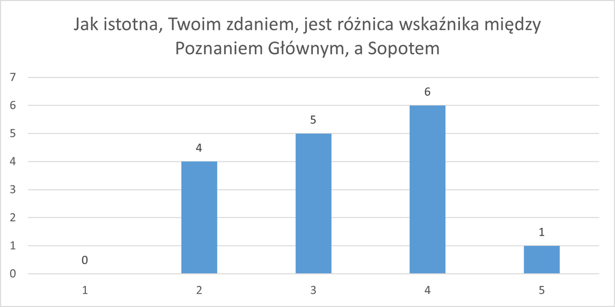

> W pytaniu nr 1 - 50% ankietowanych (8 osób) zaznaczyło **poprawną** odpowiedź - Katowice. 31,3 % (5 osób) zaznaczyło Warszawa Ochota, a 18,8% (3 osoby) zaznaczyło Warszawa Zachodnia. W pytaniu nr 2 - 6,3 % ankietowanych (1 osoba) stwierdziło, że różnica jest bardzo istotna zaznaczając na skali 5. 37.5 % (6 osób) zaznaczyło odpowiedź 4, 31,3% (5 osób) zanaczyło 3, natomiast 25% osób (4 osoby) zaznaczyło odpowiedź 2. Nikt spośród ankietowanych nie zaznaczył odowiedzi ‘mało istotna’. Średnia z ocen ankietowanych wyniosła 3,25.

## Sekcja nr 2 dotyczyła wykresu nr 2

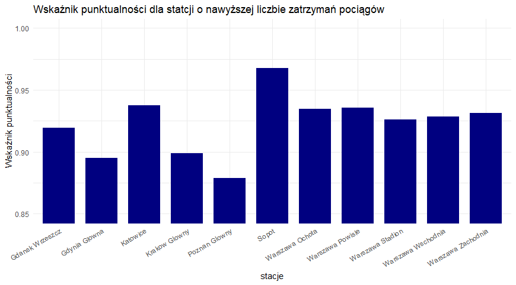

Wykres nr 2

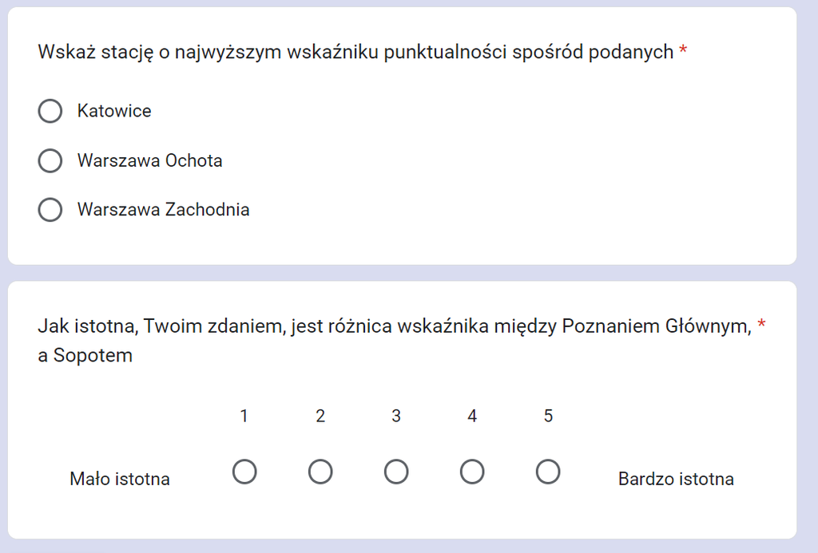

Pytania w sekcji nr 2

Pytanie nr 3

Pytanie nr 4

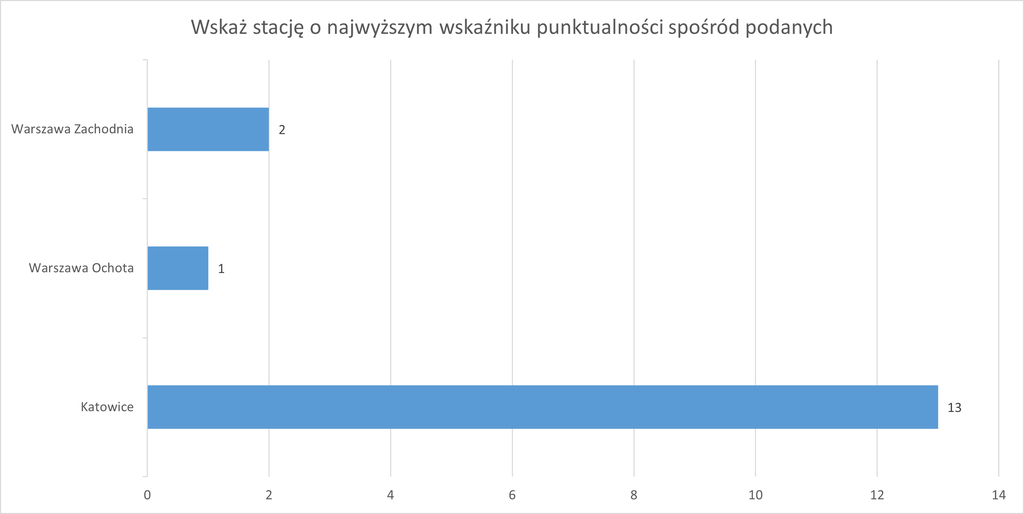

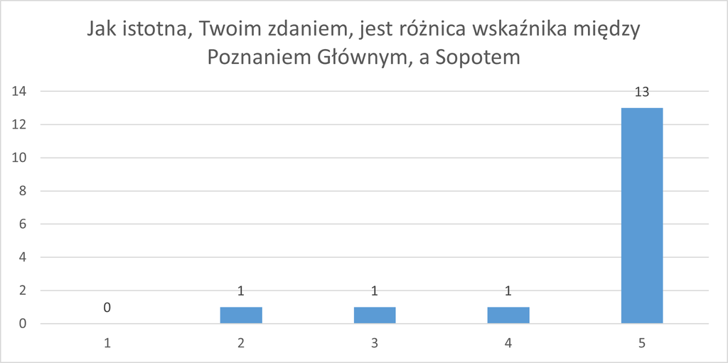

> W pytaniu nr 3 - 81,3% ankietowanych (13 osób) zaznaczyło **poprawną** odpowiedź - Katowice. 6,3 % (1 osoba) zaznaczyło Warszawa Ochota, a 12,5% (2 osoby) zaznaczyło Warszawa Zachodnia. W pytaniu nr 4 - 81,3% ankietowanych (13 osób) stwierdziło, że różnica jest bardzo istotna zaznaczając na skali 5. 6,3% akietowanych (1 osoba) zaznaczyło odpowiedzi 2, 3 i 4. Nikt spośród ankietowanych nie zaznaczył odowiedzi ‘mało istotna’. Średnia z ocen ankietowanych wyniosła 4,625.

## Sekcja nr 3 dotyczyła porównania obu wykresów

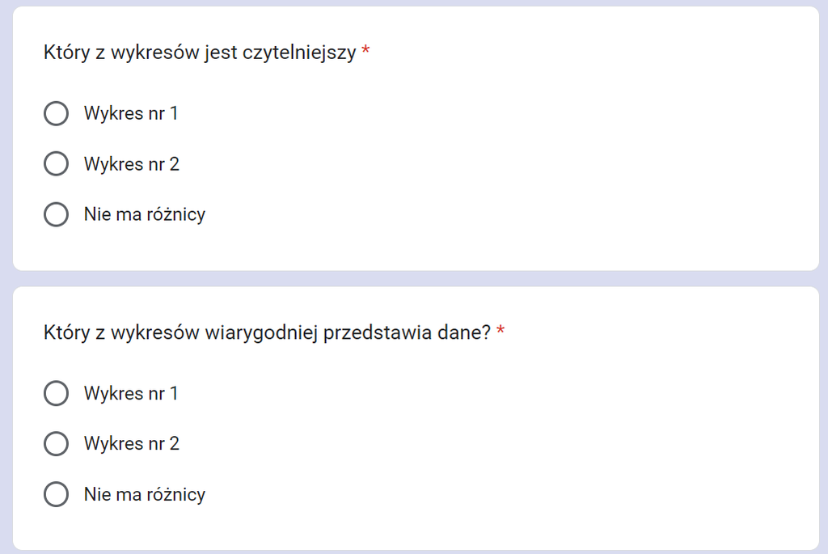

Pytania w sekcji nr 3

Pytanie nr 5

Pytanie nr 6

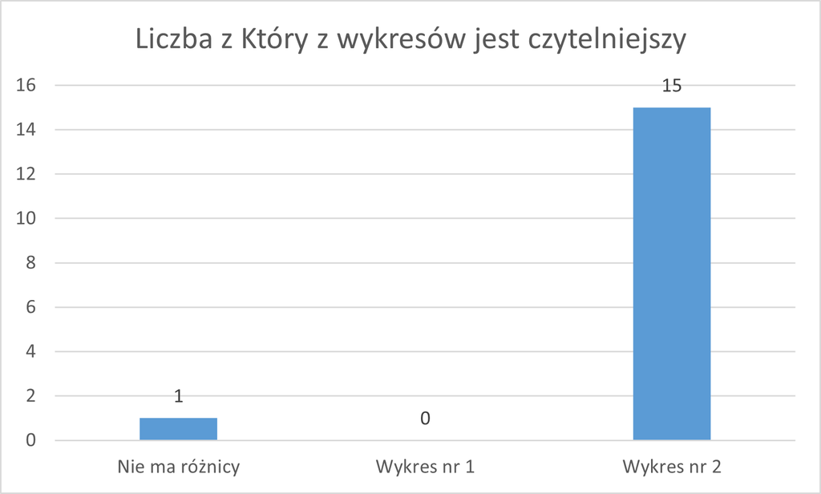

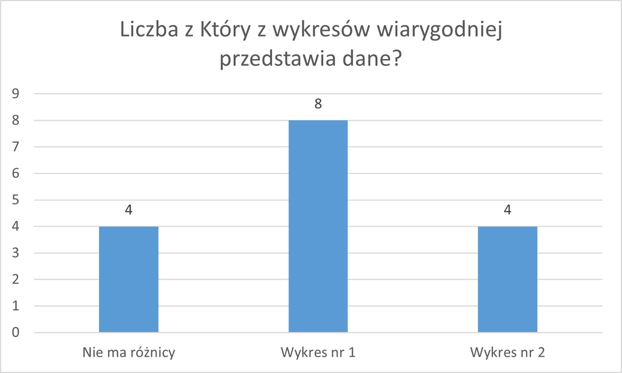

# 3. Wnioski

> Przedstawione wykresy pokazywały szczególną sytuaję - dane o zbliżonej wartości, a co za tym idzie, wysykości słupków również były do siebie zbliżone. W tym przypadku zdecydowanie bardziej czytelny, dla ankietowanych, był wykres nr 2, którego oś OY nie zaczynała się od zera. Zatem w tym przypadku zmiana skali osi pozytywnie wypłynęła na czytelność wykresu. Natomiast takie nierównomierne wyskalowanie osi wypłnęło na inną cechę - wiarygodność. W pytaniu nr 2 i 4 dotyczącym subiektywej oseny istotności różnicy konkretnymi wartościami widać znaczącą zmianę względem typu wykresu. Zmienienie skali spowodowało wzost średniej osceny użytkowników o 1,375 punktu na pięciostopniowej skali. W pytaniu nr 6 dotyczącym bezpośrednio wiarygodności 2 razy więcej osób wskazało wykres nr 1 jako bardziej wiarygodny niż wykres nr 2. Zatem zmiana skali na osiach wpływa na subiektywne postrzeganie danych przed odbiorcę. Podsumowując, modyfikacja skali na osiach może pozytywnie wpłynąć na czytelność wykresu, w przypadku danych o zbliżonej wartości, natomiast takie działanie jest manipulacją np. sybiektywnych odczuć osób co do istotności, ważności różnicy kokretnych danych.